# Project Checkpoint 4

```r
knitr::opts_chunk$set(echo = TRUE)
```

## R Markdown

```r
# Load packages
library(bayesrules)
library(tidyverse)
library(rstanarm)
library(broom.mixed)
library(tidybayes)
library(forcats)
library(bayesplot)
library(lubridate)
library(nflfastR)
library(naniar)
```

## Data Introduction

Our data comes Nflfastr. It is an R package that has scraped data into R to make it easier to create NFL analytics. The data includes play-by-play data from 1999 until the present. The package designer of is Maksim Horwitz. They use an API to directly scrape data from the NFL. This data was specifically collected to perform advanced analytics in the NFL. The NFL was and still is behind the other three major sports leagues in data sharing and analytics.

# https://developer.nfl.com/get-started/overview

# https://www.kaggle.com/maxhorowitz/nflplaybyplay2009to2016

```r
data1 <- load_pbp(2019)
```

```r
dim(data1)
```

```
## [1] 48034   372
```

```r
head(data1)
```

```
## # A tibble: 6 x 372
##   play_id game_id      old_game_id home_team away_team season_type  week posteam
##     <dbl> <chr>        <chr>       <chr>     <chr>     <chr>       <int> <chr>
## 1       1 2019_01_ATL~ 2019090804  MIN       ATL       REG             1 <NA>
## 2      36 2019_01_ATL~ 2019090804  MIN       ATL       REG             1 ATL
## 3      51 2019_01_ATL~ 2019090804  MIN       ATL       REG             1 ATL
## 4      79 2019_01_ATL~ 2019090804  MIN       ATL       REG             1 ATL
## 5     100 2019_01_ATL~ 2019090804  MIN       ATL       REG             1 ATL
## 6     121 2019_01_ATL~ 2019090804  MIN       ATL       REG             1 ATL
## # ... with 364 more variables: posteam_type <chr>, defteam <chr>,
## #   side_of_field <chr>, yardline_100 <dbl>, game_date <chr>,
## #   quarter_seconds_remaining <dbl>, half_seconds_remaining <dbl>,
## #   game_seconds_remaining <dbl>, game_half <chr>, quarter_end <dbl>,
## #   drive <dbl>, sp <dbl>, qtr <dbl>, down <dbl>, goal_to_go <dbl>, time <chr>,
## #   yrdln <chr>, ydstogo <dbl>, ydsnet <dbl>, desc <chr>, play_type <chr>,
## #   yards_gained <dbl>, shotgun <dbl>, no_huddle <dbl>, qb_dropback <dbl>, ...
```

https://www.nflfastr.com/articles/field_descriptions.html

## Part 3

Below we have the the amount of wins for each team in the 2020 season, using this prior knowledgue of team quality will help to inform us of future game win probability.

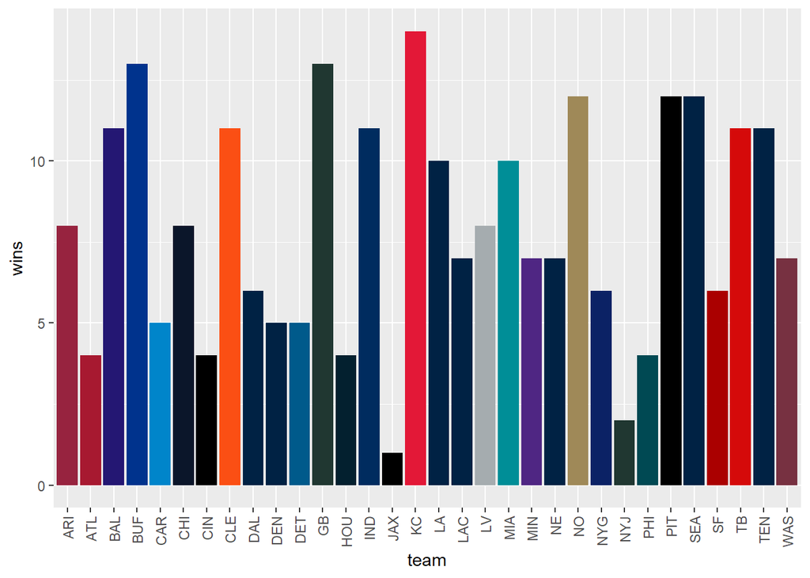

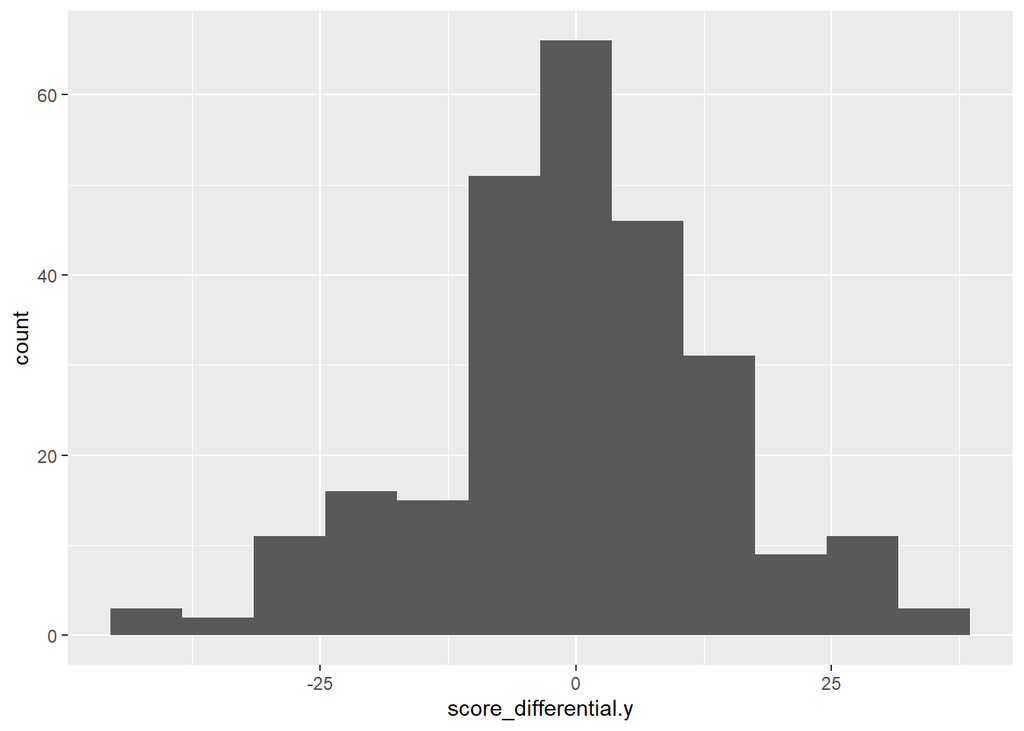

This graph above shows us that there is quite a lot of parity in the league making every score in our model matter a lot.

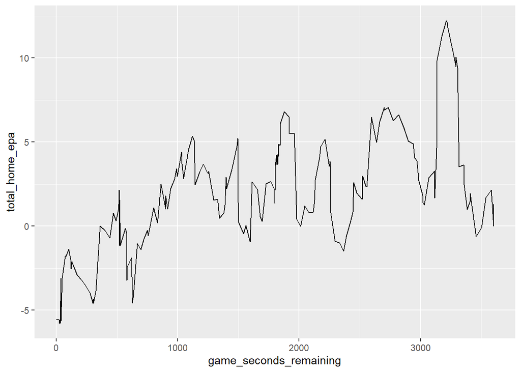

This graph shows us the epa or expected points added by each play throughout a game. This gives us insight into how the home team did throughout the game which will help us predict each teams win probability thorughout the game.

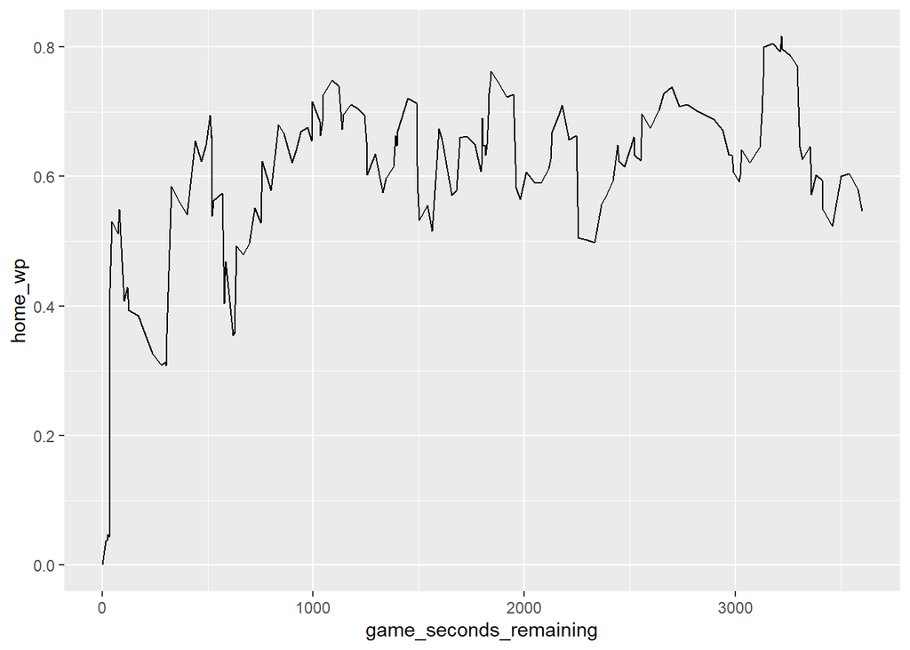

This is a win probability graph. This is ultimately what we would like to build up to and create, this was made by NFLFastR, and is something that we hope to be able to create ultimately.

## Part 4

```
#> stan_glm
#>  family:       binomial [logit]
#>  formula:      home_team_win ~ score_differential.x
#>  observations: 264
#>  predictors:   2
#> ------
#>                      Median MAD_SD
#> (Intercept)          -0.2    0.2
#> score_differential.x  0.2    0.0
#>
#> ------
#> * For help interpreting the printed output see ?print.stanreg
#> * For info on the priors used see ?prior_summary.stanreg
```

The centered intercept tells us about the log odds of the winning probability.

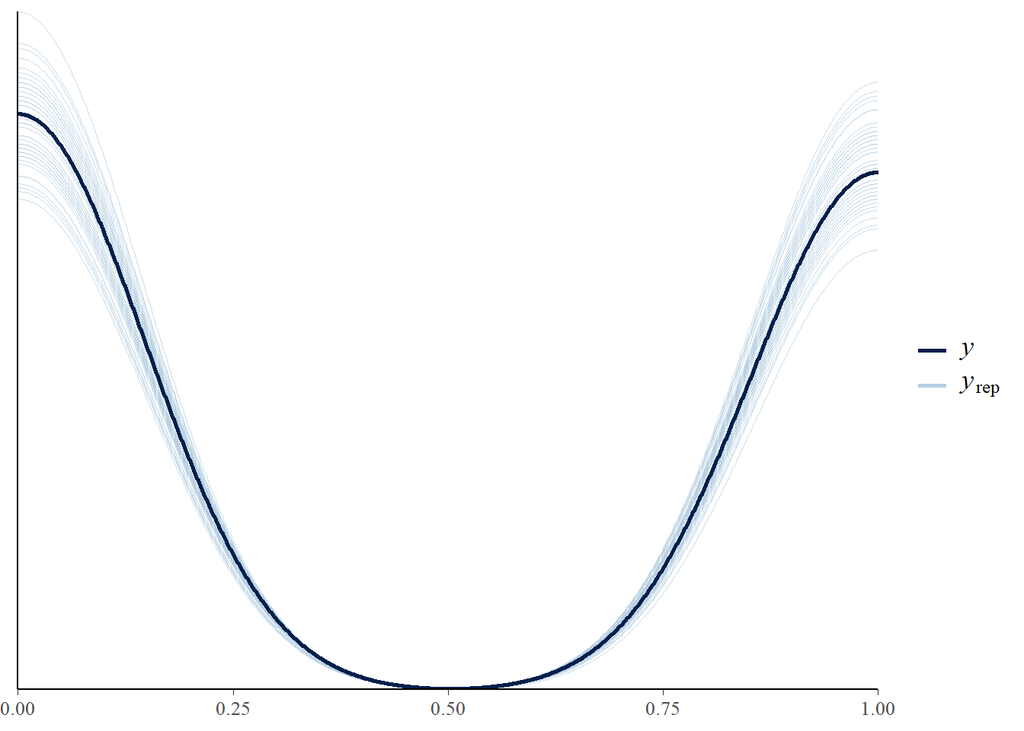

## Final Models

Our next steps are to finish creating our prior analysis on how good each team is and then we will complicate our model more and we may try to create a shiny app to make our model more interactive so that people can enter certain teams and game situations to predict the win probability for a certain team.

# Model 0

## This model uses the Vegas Spreadline when prior to the beginning of the game

```
#> $confusion_matrix
#>  y  0  1
#>  0 89 46
#>  1 40 83
#>
#> $accuracy_rates
#>
#> sensitivity      0.6747967
#> specificity      0.6592593
#> overall_accuracy 0.6666667
```

```
#> # A tibble: 2 x 3
#>   term          estimate std.error
#>   <chr>            <dbl>     <dbl>
#> 1 (Intercept)     -0.280    0.143
#> 2 spread_line.x    0.155    0.0253
```

```
#> [1] 0.7558893 1.1675960
```

# Model 1

## This model uses the Vegas spreadline and the score differential after the 1st quarter.

```
#> $confusion_matrix
#>  y   0  1
#>  0 101 34
#>  1  39 84
#>
#> $accuracy_rates
#>
#> sensitivity      0.6829268
#> specificity      0.7481481
#> overall_accuracy 0.7170543
```

```
#> $confusion_matrix
#>  y   0  1
#>  0 101 34
#>  1  39 84
#>
#> $accuracy_rates
#>
#> sensitivity      0.6829268
#> specificity      0.7481481
#> overall_accuracy 0.7170543
```

```
#> # A tibble: 3 x 5
#>   term                 estimate std.error conf.low conf.high
#>   <chr>                   <dbl>     <dbl>    <dbl>     <dbl>
#> 1 (Intercept)           -0.272     0.148   -0.565     0.0126
#> 2 score_differential.x   0.0991    0.0230   0.0554    0.146
#> 3 spread_line.x          0.151     0.0257   0.101     0.204
```

```
#> [1] 0.7615419 1.1041538 1.1625225
```

# Model 2

## This model uses the Vegas Spreadline and the halftime score differential.

```
#> $confusion_matrix
#>  y   0   1
#>  0 107  28
#>  1  23 100
#>
#> $accuracy_rates
#>
#> sensitivity      0.8130081
#> specificity      0.7925926
#> overall_accuracy 0.8023256
```

```
#> # A tibble: 3 x 5
#>   term                 estimate std.error conf.low conf.high
#>   <chr>                   <dbl>     <dbl>    <dbl>     <dbl>
#> 1 (Intercept)            -0.334    0.175   -0.685    0.00418
#> 2 score_differential.y    0.160    0.0213   0.120    0.205
#> 3 spread_line.x           0.130    0.0297   0.0741   0.190
```

```
#> [1] 0.7163236 1.1730753 1.1393820
```

# Model 3

## This model uses Vegas Spreadline and Score Differential after the 3rd Quarter.

```
#> $confusion_matrix
#>  y   0   1
#>  0 116  19
#>  1  20 103
#>
#> $accuracy_rates
#>
#> sensitivity      0.8373984
#> specificity      0.8592593
#> overall_accuracy 0.8488372
```

```
#> # A tibble: 3 x 5
#>   term                   estimate std.error conf.low conf.high
#>   <chr>                     <dbl>     <dbl>    <dbl>     <dbl>
#> 1 (Intercept)              -0.353    0.194   -0.751     0.0321
#> 2 score_differential.x.x    0.207    0.0273   0.158     0.266
#> 3 spread_line.x             0.105    0.0311   0.0451    0.168
```

```
#> [1] 0.7024977 1.2305188 1.1111630
```